# Group7 Project - Coffee Rating

Ece Gulkirpik, Johana Coronel, Mengyi Dong

10/16/2020

```r
## Install and load packages
library(tidyverse)
library(tidytuesdayR)
```

```r
library(ggplot2)
# Read data file
## coffee_rating
coffee_ratings <- readr::read_csv('https://raw.githubusercontent.com/rfordatascience/tidytuesday/master/data/2020/2020-07-07/coffee_ratings.csv')
```

# **1. Introduction**

Coffee traces its origin to a genus of plants known as Coffea. The two most commercially important species grown are varieties of *Coffeaarabica* (Arabicas) and *Coffeacanephora* (Robustas) (ISIC, 2014).

Coffee Arabica is descended from the original coffee trees discovered in Ethiopia. These trees produce a fine, mild, aromatic coffee and represent approximately 70% of the world’s coffee production. The beans are flatter and more elongated than Robusta and lower in caffeine. Most of the world’s Robusta is grown in Central and Western Africa, parts of Southeast Asia, including Indonesia and Vietnam, and in Brazil. Production of Robusta is increasing, though it accounts for only about 30% of the world market. Robusta is primarily used in blends and for instant coffees. The Robusta bean itself tends to be slightly rounder and smaller than an Arabica bean (NCA, 2020). The infographic given in Figure 1 also presents some general information about the differences between Coffee Arabica and Robusta.

[figure not shown]

Figure.1 Coffee Arabica and Robusta

*“Coffee_ratings”* dataset puts together a great amount of data on the sensorial attributes of these two coffee species which were grown and processed in many different ways by various countries. This dataset not only provides valuable information about the sensory characteristics of coffee species but also gives considerable amount of background information belong to each species including farm and company names, producers, harvest years, and certifications, etc.

“Coffee_ratings” dataset includes 43 variables in which 24 of them are character and the rest are numerical. The details about the variables can be obtained from the following R chunk:

```r
## Getting to know the variables of "Coffee_ratings" dataset

head(coffee_ratings)
```

```
## # A tibble: 6 x 43
##   total_cup_points species owner country_of_orig… farm_name lot_number mill
##              <dbl> <chr>   <chr> <chr>            <chr>     <chr>      <chr>
## 1             90.6 Arabica meta… Ethiopia         "metad p… <NA>       meta…
## 2             89.9 Arabica meta… Ethiopia         "metad p… <NA>       meta…
## 3             89.8 Arabica grou… Guatemala        "san mar… <NA>       <NA>
## 4             89   Arabica yidn… Ethiopia         "yidneka… <NA>       wole…
## 5             88.8 Arabica meta… Ethiopia         "metad p… <NA>       meta…
## 6             88.8 Arabica ji-a… Brazil            <NA>     <NA>       <NA>
## # … with 36 more variables: ico_number <chr>, company <chr>, altitude <chr>,
## #   region <chr>, producer <chr>, number_of_bags <dbl>, bag_weight <chr>,
## #   in_country_partner <chr>, harvest_year <chr>, grading_date <chr>,
## #   owner_1 <chr>, variety <chr>, processing_method <chr>, aroma <dbl>,
## #   flavor <dbl>, aftertaste <dbl>, acidity <dbl>, body <dbl>, balance <dbl>,
## #   uniformity <dbl>, clean_cup <dbl>, sweetness <dbl>, cupper_points <dbl>,
## #   moisture <dbl>, category_one_defects <dbl>, quakers <dbl>, color <chr>,
## #   category_two_defects <dbl>, expiration <chr>, certification_body <chr>,
## #   certification_address <chr>, certification_contact <chr>,
## #   unit_of_measurement <chr>, altitude_low_meters <dbl>,
## #   altitude_high_meters <dbl>, altitude_mean_meters <dbl>
```

```r
str(coffee_ratings)
```

```
## tibble [1,339 × 43] (S3: spec_tbl_df/tbl_df/tbl/data.frame)
##  $ total_cup_points     : num [1:1339] 90.6 89.9 89.8 89 88.8 ...
##  $ species              : chr [1:1339] "Arabica" "Arabica" "Arabica" "Arabica" ...
##  $ owner                : chr [1:1339] "metad plc" "metad plc" "grounds for health admin" "yidnekachew dabessa" ...
##  $ country_of_origin    : chr [1:1339] "Ethiopia" "Ethiopia" "Guatemala" "Ethiopia" ...
##  $ farm_name            : chr [1:1339] "metad plc" "metad plc" "san marcos barrancas \"san cristobal cuch" "yidnekachew dabessa coffee plantation" ...
##  $ lot_number           : chr [1:1339] NA NA NA NA ...
##  $ mill                 : chr [1:1339] "metad plc" "metad plc" NA "wolensu" ...
##  $ ico_number           : chr [1:1339] "2014/2015" "2014/2015" NA NA ...
##  $ company              : chr [1:1339] "metad agricultural developmet plc" "metad agricultural developmet plc" NA "yidnekachew debessa coffee plantation" ...
##  $ altitude             : chr [1:1339] "1950-2200" "1950-2200" "1600 - 1800 m" "1800-2200" ...
##  $ region               : chr [1:1339] "guji-hambela" "guji-hambela" NA "oromia" ...
##  $ producer             : chr [1:1339] "METAD PLC" "METAD PLC" NA "Yidnekachew Dabessa Coffee Plantation" ...
##  $ number_of_bags       : num [1:1339] 300 300 5 320 300 100 100 300 300 50 ...
##  $ bag_weight           : chr [1:1339] "60 kg" "60 kg" "1" "60 kg" ...
##  $ in_country_partner   : chr [1:1339] "METAD Agricultural Development plc" "METAD Agricultural Development plc" "Specialty Coffee Association" "METAD Agricultural Development plc" ...
##  $ harvest_year         : chr [1:1339] "2014" "2014" NA "2014" ...
##  $ grading_date         : chr [1:1339] "April 4th, 2015" "April 4th, 2015" "May 31st, 2010" "March 26th, 2015" ...
##  $ owner_1              : chr [1:1339] "metad plc" "metad plc" "Grounds for Health Admin" "Yidnekachew Dabessa" ...
##  $ variety              : chr [1:1339] NA "Other" "Bourbon" NA ...
##  $ processing_method    : chr [1:1339] "Washed / Wet" "Washed / Wet" NA "Natural / Dry" ...
##  $ aroma                : num [1:1339] 8.67 8.75 8.42 8.17 8.25 8.58 8.42 8.25 8.67 8.08 ...
##  $ flavor               : num [1:1339] 8.83 8.67 8.5 8.58 8.5 8.42 8.5 8.33 8.67 8.58 ...
##  $ aftertaste           : num [1:1339] 8.67 8.5 8.42 8.42 8.25 8.42 8.33 8.5 8.58 8.5 ...
##  $ acidity              : num [1:1339] 8.75 8.58 8.42 8.42 8.5 8.5 8.5 8.42 8.42 8.5 ...
##  $ body                 : num [1:1339] 8.5 8.42 8.33 8.5 8.42 8.25 8.25 8.33 8.33 7.67 ...
##  $ balance              : num [1:1339] 8.42 8.42 8.42 8.25 8.33 8.33 8.25 8.5 8.42 8.42 ...
##  $ uniformity           : num [1:1339] 10 10 10 10 10 10 10 10 9.33 10 ...
##  $ clean_cup            : num [1:1339] 10 10 10 10 10 10 10 10 10 10 ...
##  $ sweetness            : num [1:1339] 10 10 10 10 10 10 10 9.33 9.33 10 ...
##  $ cupper_points        : num [1:1339] 8.75 8.58 9.25 8.67 8.58 8.33 8.5 9 8.67 8.5 ...
##  $ moisture             : num [1:1339] 0.12 0.12 0 0.11 0.12 0.11 0.11 0.03 0.03 0.1 ...
##  $ category_one_defects : num [1:1339] 0 0 0 0 0 0 0 0 0 0 ...
##  $ quakers              : num [1:1339] 0 0 0 0 0 0 0 0 0 0 ...
##  $ color                : chr [1:1339] "Green" "Green" NA "Green" ...
##  $ category_two_defects : num [1:1339] 0 1 0 2 2 1 0 0 0 4 ...
##  $ expiration           : chr [1:1339] "April 3rd, 2016" "April 3rd, 2016" "May 31st, 2011" "March 25th, 2016" ...
##  $ certification_body   : chr [1:1339] "METAD Agricultural Development plc" "METAD Agricultural Development plc" "Specialty Coffee Association" "METAD Agricultural Development plc" ...
##  $ certification_address: chr [1:1339] "309fcf77415a3661ae83e027f7e5f05dad786e44" "309fcf77415a3661ae83e027f7e5f05dad786e44" "36d0d00a3724338ba7937c52a378d085f2172daa" "309fcf77415a3661ae83e027f7e5f05dad786e44" ...
##  $ certification_contact: chr [1:1339] "19fef5a731de2db57d16da10287413f5f99bc2dd" "19fef5a731de2db57d16da10287413f5f99bc2dd" "0878a7d4b9d35ddbf0fe2ce69a2062cceb45a660" "19fef5a731de2db57d16da10287413f5f99bc2dd" ...
```

[output cut: 35 more lines]

```
##   ..   cupper_points = col_double(),
##   ..   moisture = col_double(),
##   ..   category_one_defects = col_double(),
##   ..   quakers = col_double(),
##   ..   color = col_character(),
##   ..   category_two_defects = col_double(),
##   ..   expiration = col_character(),
##   ..   certification_body = col_character(),
##   ..   certification_address = col_character(),
##   ..   certification_contact = col_character(),
##   ..   unit_of_measurement = col_character(),
##   ..   altitude_low_meters = col_double(),
##   ..   altitude_high_meters = col_double(),
##   ..   altitude_mean_meters = col_double()
##   .. )
```

```r
# Summary statistics of the "Coffee Rating" dataset

summary(coffee_ratings)
```

```
##  total_cup_points   species             owner           country_of_origin
##  Min.   : 0.00    Length:1339        Length:1339        Length:1339
##  1st Qu.:81.08    Class :character   Class :character   Class :character
##  Median :82.50    Mode  :character   Mode  :character   Mode  :character
##  Mean   :82.09
##  3rd Qu.:83.67
##  Max.   :90.58
##
##   farm_name          lot_number            mill            ico_number
##  Length:1339        Length:1339        Length:1339        Length:1339
##  Class :character   Class :character   Class :character   Class :character
##  Mode  :character   Mode  :character   Mode  :character   Mode  :character
##
##
##
##
##    company            altitude            region            producer
##  Length:1339        Length:1339        Length:1339        Length:1339
##  Class :character   Class :character   Class :character   Class :character
##  Mode  :character   Mode  :character   Mode  :character   Mode  :character
##
##
##
##
##  number_of_bags    bag_weight        in_country_partner harvest_year
##  Min.   :   0.0   Length:1339        Length:1339        Length:1339
##  1st Qu.:  14.0   Class :character   Class :character   Class :character
##  Median : 175.0   Mode  :character   Mode  :character   Mode  :character
##  Mean   : 154.2
##  3rd Qu.: 275.0
##  Max.   :1062.0
##
##  grading_date         owner_1            variety          processing_method
##  Length:1339        Length:1339        Length:1339        Length:1339
##  Class :character   Class :character   Class :character   Class :character
##  Mode  :character   Mode  :character   Mode  :character   Mode  :character
##
##
##
##
```

[output cut: 33 more lines]

```
##  Length:1339           Length:1339           Length:1339
##  Class :character      Class :character      Class :character
##  Mode  :character      Mode  :character      Mode  :character
##
##
##
##
##  altitude_low_meters altitude_high_meters altitude_mean_meters
##  Min.   :     1      Min.   :     1       Min.   :     1
##  1st Qu.:  1100      1st Qu.:  1100       1st Qu.:  1100
##  Median :  1311      Median :  1350       Median :  1311
##  Mean   :  1751      Mean   :  1799       Mean   :  1775
##  3rd Qu.:  1600      3rd Qu.:  1650       3rd Qu.:  1600
##  Max.   :190164      Max.   :190164       Max.   :190164
##  NA's   :230         NA's   :230          NA's   :230
```

# **2. Analysis**

## 2.1 Total Rating Points for Each Country - Mengyi

We hope to compare the overall rating of different country and regions. To better visualize the data, we proposed to use a map chart with a choropleth world map. Choropleth map is a type of thematic map that usually used to represent an aggregate summary of a geographic characteristic (Holtz, 2018). The procedure of creating a choropleth world map with different datasets was described by kassambara(2020). We used it in this project with modifications. Here, we use a serial of color shades to represent the average/ mean overall score of coffees from different countries. Also, a summary table of the highest score, lowest score, and average score of each country is provided.

```r
## 2.1.1 Create a summary table with number of coffee rated, highest, lowest, and average rating score for each country.
ratingbycountry <- coffee_ratings %>%
  group_by(country_of_origin) %>%
  summarise(
    count = n(),
    highest_score = max(total_cup_points),
    lowest_score = min(total_cup_points),
    mean_score = mean(total_cup_points)
  )
```

```r
## From the ratingbycountry file, we see that some of the country names are not standard names. Thus, the first thing to do is to match the country names with standard names in the world map.
ratingbycountry[6,1] <- "Ivory Coast"
ratingbycountry[29,1] <- "Tanzania"
ratingbycountry[34,1] <- "Puerto Rico"
ratingbycountry[32,1] <- "USA"
ratingbycountry[33,1] <- "USA(Hawaii)"
write.table(ratingbycountry, file = "Overall_Rating_by_Country.txt")
ratingbycountry
```

```
## # A tibble: 37 x 5
##    country_of_origin count highest_score lowest_score mean_score
##    <chr>             <int>         <dbl>        <dbl>      <dbl>
##  1 Brazil              132          88.8         70.7       82.4
##  2 Burundi               2          83.3         80.3       81.8
##  3 China                16          87.2         78         82.9
##  4 Colombia            183          86           72.8       83.1
##  5 Costa Rica           51          87.2         71.8       82.8
##  6 Ivory Coast           1          79.3         79.3       79.3
##  7 Ecuador               3          83.8         78.1       80.2
##  8 El Salvador          21          85.6         79.7       83.1
##  9 Ethiopia             44          90.6         80         85.5
## 10 Guatemala           181          89.8         59.8       81.8
## # … with 27 more rows
```

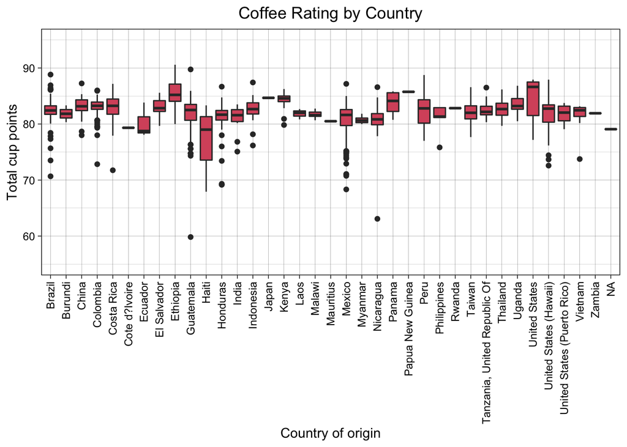

```r
## 2.1.2 Create a boxplot to display the coffee rating scores for each country.
countryrating.plot <- ggplot(coffee_ratings) +
  aes(x = country_of_origin, y = total_cup_points) +
  geom_boxplot(fill = "#d8576b") +
  labs(x = "Country of origin", y = "Total cup points", title = "Coffee Rating by Country") +
  theme_linedraw() +
  theme(axis.text.x = element_text(angle = 90, vjust = 0.5, hjust=1))+
  theme(plot.title = element_text(hjust = 0.5)) +
  ylim(55L, 95L)
ggsave("ratingbycoutry.png",  width = 12, height = 5)
countryrating.plot
```

```r
## 2.1.3 Create a choropleth map chart for world coffee rating.
## First, we need to load the packages.
require(maps)
require(viridis)
world_map <- map_data("world")
theme_set(
  theme_void()
)
## Second, we are going to select countries that are listed in coffee rating. USA and USA(Hawaii) are excluded from the coutry_of_orignin1 group, and they are listed seperately.
country_of_origin1 <- c("Brazil", "Burundi","China","Colombia","Costa Rica","Ivory Coast","Ecuador","El Salvador","Ethiopia","Guatemala","Haiti", "Honduras"
,"India", "Indonesia","Japan","Kenya","Laos", "Malawi","Mauritius","Mexico"               ,"Myanmar","Nicaragua","Panama", "Papua New Guinea","Peru", "Philippines"               ,"Rwanda", "Taiwan","Tanzania", "Thailand","Uganda", "Puerto Rico" ,"Vietnam", "Zambia")
world_map1 <- map_data ("world", region = country_of_origin1)
world_Hawaii <- map_data("world", region = "USA.Hawaii")
world_Hawaii[,5] <- "USA(Hawaii)"
world_USA <- map_data ("world", region = "USA")
world_USA1<- subset(world_USA, subregion != "Hawaii")
## Now, merge the map regions.
new_map <- rbind(world_map1,world_Hawaii,world_USA1)

## Create labels for mapping regions.
world_map1_label <- map_data ("world", region = country_of_origin1) %>%
  group_by(region) %>%
  summarise(long = mean(long), lat = mean(lat))
world_Hawaii_label <- map_data("world", region = "USA.Hawaii") %>%
  group_by(region) %>%
  summarise(long = mean(long), lat = mean(lat))
world_Hawaii_label[1,1] <- "USA(Hawaii)"
world_USA1_label<- subset(world_USA, subregion != "Hawaii")%>%
  group_by(region) %>%
  summarise(long = mean(long), lat = mean(lat))
new_map_label <- rbind(world_map1_label,world_Hawaii_label,world_USA1_label)
new_map_label
```

```
## # A tibble: 36 x 3
##    region       long   lat
##    <chr>       <dbl> <dbl>
##  1 Brazil      -55.3 -9.80
##  2 Burundi      30.0 -3.05
##  3 China       107.  35.1
##  4 Colombia    -72.8  3.47
##  5 Costa Rica  -84.0  9.76
##  6 Ecuador     -81.6 -1.64
##  7 El Salvador -88.8 13.9
##  8 Ethiopia     39.0  9.19
##  9 Guatemala   -90.2 15.6
## 10 Haiti       -72.8 18.9
## # … with 26 more rows
```

```r
## Merge coffee rating data with the map data.
world_coffee_rating <- left_join(ratingbycountry,new_map, by=c("country_of_origin" = "region"))
write.table(world_coffee_rating, file = "mapping_coffee_rating.txt")
world_coffee_rating
```

```
## # A tibble: 25,067 x 10
##    country_of_orig… count highest_score lowest_score mean_score  long   lat
##    <chr>            <int>         <dbl>        <dbl>      <dbl> <dbl> <dbl>
##  1 Brazil             132          88.8         70.7       82.4 -48.5 -27.8
##  2 Brazil             132          88.8         70.7       82.4 -48.6 -27.8
##  3 Brazil             132          88.8         70.7       82.4 -48.5 -27.6
##  4 Brazil             132          88.8         70.7       82.4 -48.5 -27.5
##  5 Brazil             132          88.8         70.7       82.4 -48.5 -27.4
##  6 Brazil             132          88.8         70.7       82.4 -48.4 -27.4
##  7 Brazil             132          88.8         70.7       82.4 -48.4 -27.5
##  8 Brazil             132          88.8         70.7       82.4 -48.4 -27.6
##  9 Brazil             132          88.8         70.7       82.4 -48.5 -27.7
## 10 Brazil             132          88.8         70.7       82.4 -48.5 -27.8
## # … with 25,057 more rows, and 3 more variables: group <dbl>, order <int>,
## #   subregion <chr>
```

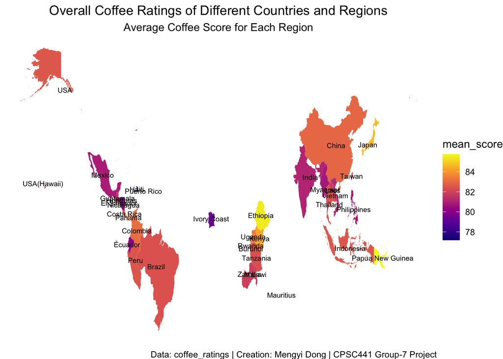

```r
## Create a choropleth world map.
coffee_rating_map <- ggplot(world_coffee_rating, aes(long, lat)) +
  geom_polygon(aes(group = group, fill = mean_score))+
  geom_text(aes(label = region), data = new_map_label, size = 2.5, hjust = 0.5) +
  scale_fill_viridis_c(option = "C") +
  labs(
    title = "Overall Coffee Ratings of Different Countries and Regions",
    subtitle = "Average Coffee Score for Each Region",
    caption = "Data: coffee_ratings | Creation: Mengyi Dong | CPSC441 Group-7 Project"
  ) +
  theme(plot.title = element_text(hjust = 0.5)) +
  theme(plot.subtitle = element_text(hjust = 0.5))
ggsave("map_coffee_ratings.png",  width = 12, height = 5)
coffee_rating_map
```

From the map, we are able to tell which country/ region’s coffee has the highest overall quality. On the color scale, bright yellow represents the highest average rating score, while the purple represents the lowest rating score. Based on the colors, coffee from Ethiopia and Papua New Guinea has the best overall quality followed by the coffee from Japan. However, coffee from Ivory Coast and Ecuador has relative lower scores compare to other countries.